# Final Project: Spam Filter Analysis

## *Classification Tree*

After apply the normal surpvised clssification technique, consider the Tree_based method. Classification Tree is good for interpretation since we do the prediction after split data into different feature space based on the split rule. However, there is still an big disadtantage bacause of test predition error caused by overfitting. Therefore prune is nessary to build an stable model. We use tree() method in the tree package to help use grow and prune the tree.

As KNN, cross validtioin is still used to tune the paratemer alpha which corresponds to different Tree size |T|. The plot below show the relationship between the *nodesize* and *deviance of cross validation*.

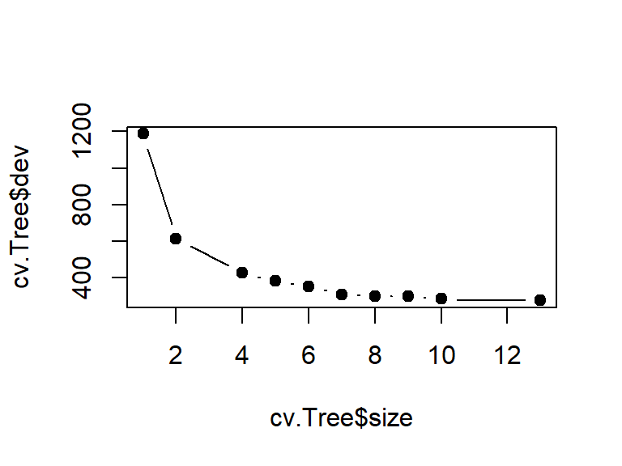

```r
# Build the whole Tree
Tree_Full = tree(type ~ ., data = spam_trn)
# Cross Validation to Select Best Tune Parameter
cv.Tree = cv.tree(Tree_Full, FUN = prune.misclass)
plot(cv.Tree$size, cv.Tree$dev, type = "b", pch = 19)
```

```r
best.node = cv.Tree$size[cv.Tree$dev == min(cv.Tree$dev)][1]
```

A final tree modle is built based on the best tune paramter.  
The below tree graph shows the split rule including selected variable $X_j$ and cutoff $c$, branches and ternimal nodes which is 13

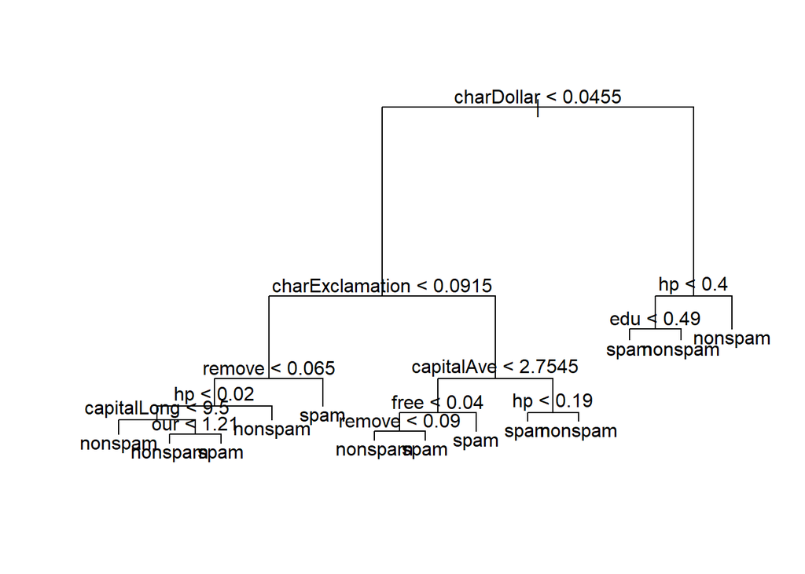

```r
# Prune the Tree by the best node
Tree_Final = prune.misclass(Tree_Full, best = best.node)
plot(Tree_Final)
text(Tree_Final)
```

```r
# Make Prediciton & Test Missclassifictaion Rate
Pred_Final = predict(Tree_Final, spam_tst, type = "class")
(conftable_CT = table(Pred_Final, spam_tst$type))
```

```
##
## Pred_Final nonspam spam
##    nonspam     904   75
##    spam         72  550
```

```r
(missrate_CT = mean( Pred_Final != spam_tst$type))
```

```
## [1] 0.09181761
```

The missclassifiation rate is similar with LDA which is better than KNN, but still cannot campared with Logistic Classifier.

### *Sensitivity & Specificity Analysis*

In our case, classification of spam, the harm of these errors are unequal. We can’t allow important information, say, a job offer, miss our inbox and get sent to the spam folder. On the other hand, the spam email that would make it to an inbox (false negatives) are easily dealt with, just delete them. Therefore, instead of simply evaluating a classifier based on its misclassification rate (or accuracy), we’ll create two additional functions,to calculate sensitivity and specificity.

For Spam filter, we want to lower the rate which the useful(non-spam) email to be classified into spam. Therefore, we want to lower the False Postive Rate which means improve specificity. An effective way is to modify the cutoff in Logisticl Classifier.

- From above all we have many usel Models to successfully classify the spam with high accruacy.
- The Error of **False Postive** is much more harmful than **False Negtive** for the Spam Filter.
- Improve **sensitivity** or **specificity** at the expense of the **overall accuracy**

```r
# Sensitivity: True positive rate
get_sens = function(conf_mat) {
  conf_mat[2, 2] / sum(conf_mat[, 2])
}
# Specificity: True negative rate
get_spec = function(conf_mat) {
  conf_mat[1, 1] / sum(conf_mat[, 1])
}
# Original Logistic Classifier
get_sens(conftable_logistic)
```

```
## [1] 0.8816
```

```r
get_spec(conftable_logistic)
```

```
## [1] 0.9569672
```

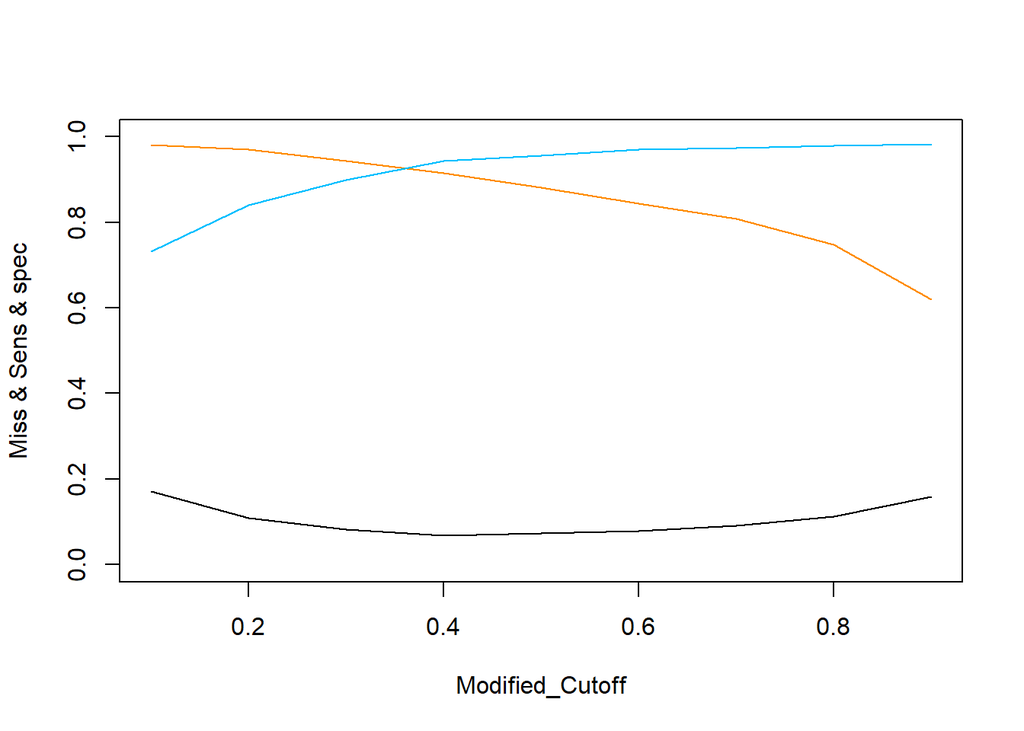

```r
#Modify Cutoff to Improve Specificity
Modified_Cutoff = seq(0.1, 0.9, by = 0.1)
specificity = numeric(length(Modified_Cutoff))
Sensitivity = numeric(length(Modified_Cutoff))
Missrate =   numeric(length(Modified_Cutoff))

for(i in 1:length(Modified_Cutoff)){

  tst_pred_Modified = ifelse(predict(logistic_model, spam_tst, type = "response") > Modified_Cutoff[i], "spam", "nonspam")
  conftable_Modified = table(tst_pred_Modified, spam_tst$type)
  Missrate[i] = mean(tst_pred_Modified != spam_tst$type)
  Sensitivity[i] = get_sens(conftable_Modified)
  specificity[i] = get_spec(conftable_Modified)

}

plot(Modified_Cutoff, Missrate, type = "l", col = "black", ylim = c(0,1), ylab = "Miss & Sens & spec" )
points(Modified_Cutoff, Sensitivity, type = "l", col = "darkorange")
points(Modified_Cutoff, specificity, type = "l", col = "deepskyblue")
```

```r
Results = data.frame(c(Missrate[9], missrate_logistic, missrate_LDA, missrate_knn, missrate_CT, missrate_RT,missrate_svm),
                     c(Sensitivity[9], get_sens(conftable_logistic), get_sens(conftable_LDA), get_sens(conftable_knn), get_sens(conftable_CT), get_sens(conftable_RT),get_sens(conftable_SVM) ),
                     c(specificity[9], get_spec(conftable_logistic), get_spec(conftable_LDA), get_spec(conftable_knn), get_spec(conftable_CT), get_spec(conftable_RT),get_spec(conftable_SVM) ))
rownames(Results) = c("Modified Logistic","Logistic", "LDA","KNN", "Classification Tree", "Random Forest","SVM")
colnames(Results) = c("Missclassification", "Sensitivity", "Specificity")
Results
```

```
##                     Missclassification Sensitivity Specificity
## Modified Logistic           0.15865084      0.6192   0.9836066
## Logistic                    0.07245472      0.8816   0.9569672
## LDA                         0.11055590      0.7904   0.9528689
## KNN                         0.19862586      0.7440   0.8381148
## Classification Tree         0.09181761      0.8800   0.9262295
## Random Forest               0.05184260      0.9248   0.9631148
## SVM                         0.06121174      0.9104   0.9569672
```

According to this Final Restuls, Randomforsest Model is the best in the view of Test Missclassification Rate, SVM with radial is the second. For a more practical use of spam filter (pay much more attention on Specificity), We choose the selected Logistic classifier with 0.9 cutoff.

## Conclusion and Discussion

### Summary of Scientific Findings:

- Most of the Classification Model work successfully in this Spam Filter
- Random Forest and SVM are the best for the Spam Filter in the view of miss classification rate
- charDollar(“$”), word “hp” and charExclamation(“!”) are the most effective variables for the spam filter, the “uninterrupted capita”l words also has some influence on spam filter.
- Miss Rate: Random Forest is much less than Classification Tree, which indicates that bootstrap and randomness play important roles in the prediction error and model stability.
- From the test misclassification rate, it proves our assumptions before that KNN and LDA are bad for this high-dimension and crowded-points data.
- Combining with the harmful of Type I and Type II error, we tune the cutoff = 0.9 in the Logistic Model to make a more reasonable and practical spam filter.

### Potential Pitfalls:

The whole dataset has only 4601 rows which is not enough to train and test our models sufficiently. To make the results more convincing, it would be better to gather more emails and collect more data information. In addition This dataset is from Year 1999, therefore, the information extracted from each email could be outdated, to keep our spam filter as well as the analysis fashion and practical, we need to keep updating our spam database.

### Concluding Remarks:

After this project, we constructed a both theoretical-perfect and practical spam filter according to the dataset, what we need to do in the future is maintaining it with different emails data. This project offer us an opportunity to apply what we learned throughout the whole semester and apply them on real-world problems.